# Assignment 3 - Linear Algebra

## Alexander Mervar - 2.2.2022

### Question 1

Using Desmos.com or your favorite plotting software, plot the lines defined by each of the two equations on a graph, and then solve for x and y (2 pts)

4x + 3y = 31  
2x – 8y = ‐32

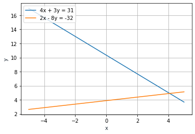

```python
import numpy as np
import matplotlib.pyplot as plt
from matplotlib import colors
import math

x1 = np.linspace(-5, 5, 100)
y1 = (31 - 4*x1)/3

x2 = np.linspace(-5, 5, 100)
y2 = (-31-2*x2)/-8

plt.plot(x1, y1, label='4x + 3y = 31')
plt.plot(x2, y2, label='2x - 8y = -32')
plt.xlabel('x', color='#1C2833')
plt.ylabel('y', color='#1C2833')
plt.legend(loc='upper left')
plt.grid()
plt.show()
```

**As seen in the graph above, the intersection of the two lines is at (4,5). This can be checked by plugging the x and y values into the equations and checking their validity.**

$$ 4(4) + 3(5) = 31 \\ 2(4) - (8(5) = -32 $$

### Question 2

Write the system of equations above as a matrix multiplication expression (2 pts)

**Below is the matrix multiplication expression.**

$$ \begin{bmatrix} 4 & 3\\ 2 & -8 \end{bmatrix} * \begin{bmatrix} x \\ y \end{bmatrix} = \begin{bmatrix} 31 \\ -32 \end{bmatrix} $$

### Question 3

What is the transpose of $\begin{bmatrix}1 & 4 & 7 \\ 2 & 3 & 0\end{bmatrix}$ ? (2 pts)

**Below is the transpose of** $\begin{bmatrix}1 & 4 & 7 \\ 2 & 3 & 0\end{bmatrix}$

$$ \begin{bmatrix} 1 & 2 \\ 4 & 3 \\ 7 & 0 \end{bmatrix} $$

### Question 4

Can you invert the matrix c= $\begin{bmatrix}1 & 2 \\ 3 & 6\end{bmatrix}$? Why or why not? (2 pts)

**You cannot take the inverse of this matrix because the matrix is not linearly independent.** $R_2 = R_1*2$

### Question 5

Calculate the dot product of the vectors a = [1 4 ‐3], and b = [2 ‐4 1]. What is the angle between them, in degrees? (2 pts)

$$ \begin{bmatrix} 1 & 4 & -3 \end{bmatrix} \cdot \begin{bmatrix} 2 & -4 & 1 \end{bmatrix} = 2(1) - 4(4) + -3(1) = -17 $$

```python
# Angle between two vectors (1 4 -3)(2 -4 1) with dot product = -17

inside = -17/(np.sqrt(1**2 + 4**2 + 3**2) * np.sqrt(2**2 + 4**2 + 1**2))
answer = math.degrees(np.arccos(inside))

print("Angle: " + str(answer) + " degrees")
```

```
Angle: 136.67995988980923 degrees
```

### Question 6

A perceptron has a weight matrix of W = [1 ‐3 4] and bias b = ‐2. Using the equation V = $\sum_{i=1}^N W_ix_i + bias$, determine whether the input pattern x = [3 5 ‐4] is sufficient to “activate” the perceptron with V > 0. (2 pts)

$V = 3*1 + 5*-3 + -4*4 + -2 = -30$**, which is less than 0, so the perceptron does not activate.**

### Question 7

Using python, write a script that takes the two equations below.

8x +2y = 52  
3x – 4y = 29

In your python script, do the following (3 pts):

a) represent the system of equations as numpy arrays.  
b) solve the system using matrix inversion  
c) plot the two lines corresponding to each equation on a 2D graph using pyplot

Submit your python code and the plot of question 7c to Canvas, along with your answers to the assignment.

```
[[ 8  2]
 [ 3 -4]]
[[ 0.10526316  0.05263158]
 [ 0.07894737 -0.21052632]]
Solution of Ax = B: [ 7. -2.]
```

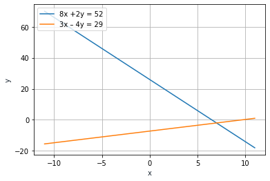

```python
matrixList = [[8, 2],[3, -4]]
A = np.array(matrixList)
print(A)

invA = np.linalg.inv(A)
print(invA)

B = np.array([52,29])

X = np.dot(invA, B)

print("Solution of Ax = B: " + str(X))

x1 = np.linspace(-11, 11, 100)
y1 = (52-8*x1)/2

x2 = np.linspace(-11, 11, 100)
y2 = (29-3*x2)/-4

plt.plot(x1, y1, label='8x +2y = 52')
plt.plot(x2, y2, label='3x – 4y = 29')
plt.xlabel('x', color='#1C2833')
plt.ylabel('y', color='#1C2833')
plt.legend(loc='upper left')
plt.grid()
plt.show()
```